# jobs

## 0. Описать задачу словами

Набор данных содержит 18 тысяч описаний вакансий, из которых около 800 являются поддельными. Данные состоят как из текстовой информации, так и из метаинформации о вакансиях. Набор данных можно использовать для создания моделей классификации, которые могут определять описания вакансий, которые являются мошенническими.

## 1. Прочитать данные

```python
import numpy as np
import pandas as pd
import seaborn as sns
import matplotlib.pyplot as plt

import warnings
warnings.filterwarnings('ignore')
```

```python
df = pd.read_csv('fake_job_postings.csv')
df.head(5)
```

|  | job_id | title | location | department | salary_range | company_profile | description | requirements | benefits | telecommuting | has_company_logo | has_questions | employment_type | required_experience | required_education | industry | function | fraudulent |
| --- | --- | --- | --- | --- | --- | --- | --- | --- | --- | --- | --- | --- | --- | --- | --- | --- | --- | --- |
| 0 | 1 | Marketing Intern | US, NY, New York | Marketing | NaN | We're Food52, and we've created a groundbreaki... | Food52, a fast-growing, James Beard Award-winn... | Experience with content management systems a m... | NaN | 0 | 1 | 0 | Other | Internship | NaN | NaN | Marketing | 0 |
| 1 | 2 | Customer Service - Cloud Video Production | NZ, , Auckland | Success | NaN | 90 Seconds, the worlds Cloud Video Production ... | Organised - Focused - Vibrant - Awesome!Do you... | What we expect from you:Your key responsibilit... | What you will get from usThrough being part of... | 0 | 1 | 0 | Full-time | Not Applicable | NaN | Marketing and Advertising | Customer Service | 0 |
| 2 | 3 | Commissioning Machinery Assistant (CMA) | US, IA, Wever | NaN | NaN | Valor Services provides Workforce Solutions th... | Our client, located in Houston, is actively se... | Implement pre-commissioning and commissioning ... | NaN | 0 | 1 | 0 | NaN | NaN | NaN | NaN | NaN | 0 |
| 3 | 4 | Account Executive - Washington DC | US, DC, Washington | Sales | NaN | Our passion for improving quality of life thro... | THE COMPANY: ESRI – Environmental Systems Rese... | EDUCATION: Bachelor’s or Master’s in GIS, busi... | Our culture is anything but corporate—we have ... | 0 | 1 | 0 | Full-time | Mid-Senior level | Bachelor's Degree | Computer Software | Sales | 0 |
| 4 | 5 | Bill Review Manager | US, FL, Fort Worth | NaN | NaN | SpotSource Solutions LLC is a Global Human Cap... | JOB TITLE: Itemization Review ManagerLOCATION:... | QUALIFICATIONS:RN license in the State of Texa... | Full Benefits Offered | 0 | 1 | 1 | Full-time | Mid-Senior level | Bachelor's Degree | Hospital & Health Care | Health Care Provider | 0 |

## 2. Визуализировать данные и вычислить основные характеристики (среднее, разброс, корреляционную матрицу и т.д.). Интерпретировать.

```python
df.shape
```

```
(17880, 18)
```

```python
df.info()
```

```
<class 'pandas.core.frame.DataFrame'>
RangeIndex: 17880 entries, 0 to 17879
Data columns (total 18 columns):
 #   Column               Non-Null Count  Dtype
---  ------               --------------  -----
 0   job_id               17880 non-null  int64
 1   title                17880 non-null  object
 2   location             17534 non-null  object
 3   department           6333 non-null   object
 4   salary_range         2868 non-null   object
 5   company_profile      14572 non-null  object
 6   description          17879 non-null  object
 7   requirements         15185 non-null  object
 8   benefits             10670 non-null  object
 9   telecommuting        17880 non-null  int64
 10  has_company_logo     17880 non-null  int64
 11  has_questions        17880 non-null  int64
 12  employment_type      14409 non-null  object
 13  required_experience  10830 non-null  object
 14  required_education   9775 non-null   object
 15  industry             12977 non-null  object
 16  function             11425 non-null  object
 17  fraudulent           17880 non-null  int64
dtypes: int64(5), object(13)
memory usage: 2.5+ MB
```

```python
df.describe().T
```

|  | count | mean | std | min | 25% | 50% | 75% | max |
| --- | --- | --- | --- | --- | --- | --- | --- | --- |
| job_id | 17880.0 | 8940.500000 | 5161.655742 | 1.0 | 4470.75 | 8940.5 | 13410.25 | 17880.0 |
| telecommuting | 17880.0 | 0.042897 | 0.202631 | 0.0 | 0.00 | 0.0 | 0.00 | 1.0 |
| has_company_logo | 17880.0 | 0.795302 | 0.403492 | 0.0 | 1.00 | 1.0 | 1.00 | 1.0 |
| has_questions | 17880.0 | 0.491723 | 0.499945 | 0.0 | 0.00 | 0.0 | 1.00 | 1.0 |
| fraudulent | 17880.0 | 0.048434 | 0.214688 | 0.0 | 0.00 | 0.0 | 0.00 | 1.0 |

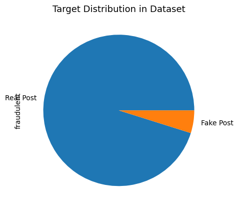

```python
fig, axes = plt.subplots(ncols=1, figsize=(17, 5), dpi=100)

df["fraudulent"].value_counts().plot(kind='pie', labels=['Real Post', 'Fake Post'])
axes.set_title('Target Distribution in Dataset', fontsize=13)
```

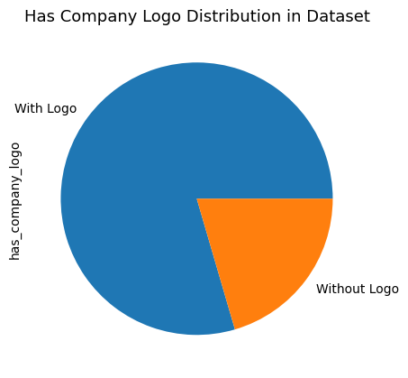

```python
fig, axes = plt.subplots(ncols=1, figsize=(17, 5), dpi=100)

df["has_company_logo"].value_counts().plot(kind='pie', labels=['With Logo', 'Without Logo'])
axes.set_title('Has Company Logo Distribution in Dataset', fontsize=13)
```

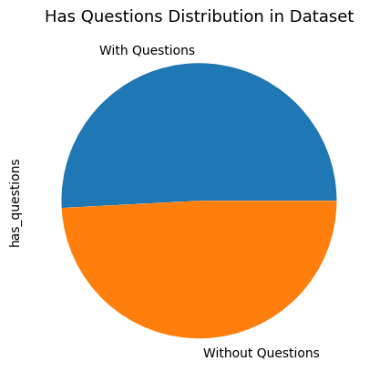

```python
fig, axes = plt.subplots(ncols=1, figsize=(17, 5), dpi=100)

df["has_questions"].value_counts().plot(kind='pie', labels=['With Questions', 'Without Questions'])
axes.set_title('Has Questions Distribution in Dataset', fontsize=13)
```

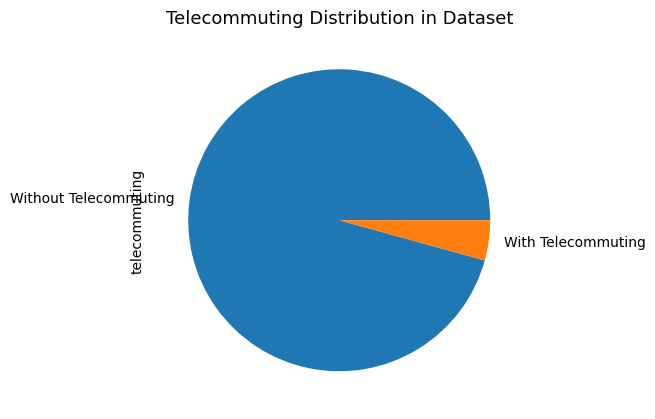

```python
fig, axes = plt.subplots(ncols=1, figsize=(17, 5), dpi=100)

df["telecommuting"].value_counts().plot(kind='pie', labels=['Without Telecommuting', 'With Telecommuting'])
axes.set_title('Telecommuting Distribution in Dataset', fontsize=13)
```

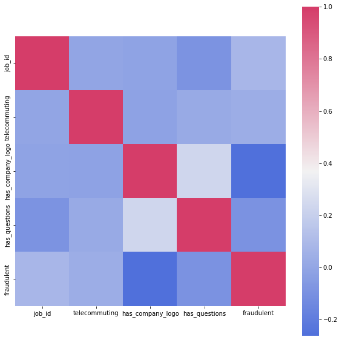

```python
plt.figure(figsize = (10,10))
corr = df.corr()
sns.heatmap(corr , mask=np.zeros_like(corr, dtype=np.bool) , cmap=sns.diverging_palette(-100,0,as_cmap=True) , square = True)
```

## 3. Обработать пропущенные значения (или убедиться, что их нет)

```python
df.head()
```

|  | job_id | title | location | department | salary_range | company_profile | description | requirements | benefits | telecommuting | has_company_logo | has_questions | employment_type | required_experience | required_education | industry | function | fraudulent |
| --- | --- | --- | --- | --- | --- | --- | --- | --- | --- | --- | --- | --- | --- | --- | --- | --- | --- | --- |
| 0 | 1 | Marketing Intern | US, NY, New York | Marketing | NaN | We're Food52, and we've created a groundbreaki... | Food52, a fast-growing, James Beard Award-winn... | Experience with content management systems a m... | NaN | 0 | 1 | 0 | Other | Internship | NaN | NaN | Marketing | 0 |
| 1 | 2 | Customer Service - Cloud Video Production | NZ, , Auckland | Success | NaN | 90 Seconds, the worlds Cloud Video Production ... | Organised - Focused - Vibrant - Awesome!Do you... | What we expect from you:Your key responsibilit... | What you will get from usThrough being part of... | 0 | 1 | 0 | Full-time | Not Applicable | NaN | Marketing and Advertising | Customer Service | 0 |
| 2 | 3 | Commissioning Machinery Assistant (CMA) | US, IA, Wever | NaN | NaN | Valor Services provides Workforce Solutions th... | Our client, located in Houston, is actively se... | Implement pre-commissioning and commissioning ... | NaN | 0 | 1 | 0 | NaN | NaN | NaN | NaN | NaN | 0 |
| 3 | 4 | Account Executive - Washington DC | US, DC, Washington | Sales | NaN | Our passion for improving quality of life thro... | THE COMPANY: ESRI – Environmental Systems Rese... | EDUCATION: Bachelor’s or Master’s in GIS, busi... | Our culture is anything but corporate—we have ... | 0 | 1 | 0 | Full-time | Mid-Senior level | Bachelor's Degree | Computer Software | Sales | 0 |
| 4 | 5 | Bill Review Manager | US, FL, Fort Worth | NaN | NaN | SpotSource Solutions LLC is a Global Human Cap... | JOB TITLE: Itemization Review ManagerLOCATION:... | QUALIFICATIONS:RN license in the State of Texa... | Full Benefits Offered | 0 | 1 | 1 | Full-time | Mid-Senior level | Bachelor's Degree | Hospital & Health Care | Health Care Provider | 0 |

Пропущенные значения имеются, заменим их на пустые строки

```python
df.fillna(" ",inplace = True)
```

```python
df.head()
```

|  | job_id | title | location | department | salary_range | company_profile | description | requirements | benefits | telecommuting | has_company_logo | has_questions | employment_type | required_experience | required_education | industry | function | fraudulent |
| --- | --- | --- | --- | --- | --- | --- | --- | --- | --- | --- | --- | --- | --- | --- | --- | --- | --- | --- |
| 0 | 1 | Marketing Intern | US, NY, New York | Marketing |  | We're Food52, and we've created a groundbreaki... | Food52, a fast-growing, James Beard Award-winn... | Experience with content management systems a m... |  | 0 | 1 | 0 | Other | Internship |  |  | Marketing | 0 |
| 1 | 2 | Customer Service - Cloud Video Production | NZ, , Auckland | Success |  | 90 Seconds, the worlds Cloud Video Production ... | Organised - Focused - Vibrant - Awesome!Do you... | What we expect from you:Your key responsibilit... | What you will get from usThrough being part of... | 0 | 1 | 0 | Full-time | Not Applicable |  | Marketing and Advertising | Customer Service | 0 |
| 2 | 3 | Commissioning Machinery Assistant (CMA) | US, IA, Wever |  |  | Valor Services provides Workforce Solutions th... | Our client, located in Houston, is actively se... | Implement pre-commissioning and commissioning ... |  | 0 | 1 | 0 |  |  |  |  |  | 0 |
| 3 | 4 | Account Executive - Washington DC | US, DC, Washington | Sales |  | Our passion for improving quality of life thro... | THE COMPANY: ESRI – Environmental Systems Rese... | EDUCATION: Bachelor’s or Master’s in GIS, busi... | Our culture is anything but corporate—we have ... | 0 | 1 | 0 | Full-time | Mid-Senior level | Bachelor's Degree | Computer Software | Sales | 0 |
| 4 | 5 | Bill Review Manager | US, FL, Fort Worth |  |  | SpotSource Solutions LLC is a Global Human Cap... | JOB TITLE: Itemization Review ManagerLOCATION:... | QUALIFICATIONS:RN license in the State of Texa... | Full Benefits Offered | 0 | 1 | 1 | Full-time | Mid-Senior level | Bachelor's Degree | Hospital & Health Care | Health Care Provider | 0 |

## 4. Обработать категориальные признаки

Список категориальных признаков

```python
cat_cols = [
    "telecommuting",
    "has_company_logo",
    "has_questions",
    "employment_type",
    "required_experience",
    "required_education"
]
```

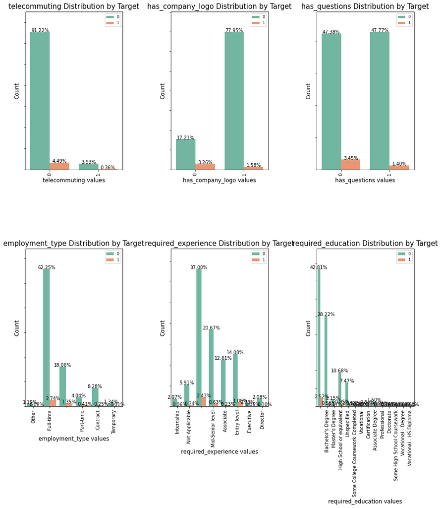

```python
# visualizating catagorical variable by target
import matplotlib.gridspec as gridspec # to do the grid of plots
grid = gridspec.GridSpec(3, 3, wspace=0.5, hspace=0.5) # The grid of chart
plt.figure(figsize=(15,25)) # size of figure

for n, col in enumerate(df[cat_cols]):
    ax = plt.subplot(grid[n]) # feeding the figure of grid
    sns.countplot(x=col, data=df, hue='fraudulent', palette='Set2')
    ax.set_ylabel('Count', fontsize=12) # y axis label
    ax.set_title(f'{col} Distribution by Target', fontsize=15) # title label
    ax.set_xlabel(f'{col} values', fontsize=12) # x axis label
    xlabels = ax.get_xticklabels()
    ylabels = ax.get_yticklabels()
    ax.set_xticklabels(xlabels,  fontsize=10)
    ax.set_yticklabels(ylabels,  fontsize=10)
    plt.legend(fontsize=8)
    plt.xticks(rotation=90)
    total = len(df)
    sizes=[] # Get highest values in y
    for p in ax.patches: # loop to all objects
        height = p.get_height()
        sizes.append(height)
        ax.text(p.get_x()+p.get_width()/2.,
                height + 3,
                '{:1.2f}%'.format(height/total*100),
                ha="center", fontsize=10)
    ax.set_ylim(0, max(sizes) * 1.15) #set y limit based on highest heights
```

Объединим все текстовые признаки в один

```python
df['text'] = df['title'] + ' ' \
           + df['location'] + ' ' \
           + df['department'] + ' ' \
           + df['company_profile'] + ' ' \
           + df['description'] + ' ' \
           + df['requirements'] + ' ' \
           + df['benefits'] + ' ' \
           + df['employment_type'] + ' ' \
           + df['required_education'] + ' ' \
           + df['industry'] + ' ' \
           + df['function']

del df['title']
del df['location']
del df['department']
del df['company_profile']
del df['description']
del df['requirements']
del df['benefits']
del df['employment_type']
del df['required_experience']
del df['required_education']
del df['industry']
del df['function']
```

```python
 df.text[0]
```

```
"Marketing Intern US, NY, New York Marketing We're Food52, and we've created a groundbreaking and award-winning cooking site. We support, connect, and celebrate home cooks, and give them everything they need in one place.We have a top editorial, business, and engineering team. We're focused on using…
```

```python
df.head()
```

|  | job_id | salary_range | telecommuting | has_company_logo | has_questions | fraudulent | text |
| --- | --- | --- | --- | --- | --- | --- | --- |
| 0 | 1 |  | 0 | 1 | 0 | 0 | Marketing Intern US, NY, New York Marketing We... |
| 1 | 2 |  | 0 | 1 | 0 | 0 | Customer Service - Cloud Video Production NZ, ... |
| 2 | 3 |  | 0 | 1 | 0 | 0 | Commissioning Machinery Assistant (CMA) US, IA... |
| 3 | 4 |  | 0 | 1 | 0 | 0 | Account Executive - Washington DC US, DC, Wash... |
| 4 | 5 |  | 0 | 1 | 1 | 0 | Bill Review Manager US, FL, Fort Worth SpotS... |

Отбросим колоинку `job_id`

```python
del df['job_id']
```

Значения `salary_range` встречаются крайне редко, поэтому отбросим и эту колонку

```python
del df['salary_range']
```

```python
df.head()
```

|  | telecommuting | has_company_logo | has_questions | fraudulent | text |
| --- | --- | --- | --- | --- | --- |
| 0 | 0 | 1 | 0 | 0 | Marketing Intern US, NY, New York Marketing We... |
| 1 | 0 | 1 | 0 | 0 | Customer Service - Cloud Video Production NZ, ... |
| 2 | 0 | 1 | 0 | 0 | Commissioning Machinery Assistant (CMA) US, IA... |
| 3 | 0 | 1 | 0 | 0 | Account Executive - Washington DC US, DC, Wash... |
| 4 | 0 | 1 | 1 | 0 | Bill Review Manager US, FL, Fort Worth SpotS... |

Обработаем текстовые признаки

#### 1. Составим список стоп слов

```python
import nltk
nltk.download('all', quiet=True)

from nltk.corpus import stopwords
from string import punctuation

stop = set(stopwords.words('english'))
punctuation = list(punctuation)
stop.update(punctuation)
```

Выполним лемматизацию

```python
from nltk.stem import WordNetLemmatizer
from nltk import pos_tag
from nltk.corpus import wordnet

def get_simple_pos(tag):
    if tag.startswith('J'):
        return wordnet.ADJ
    elif tag.startswith('V'):
        return wordnet.VERB
    elif tag.startswith('N'):
        return wordnet.NOUN
    elif tag.startswith('R'):
        return wordnet.ADV
    else:
        return wordnet.NOUN

lemmatizer = WordNetLemmatizer()
def lemmatize_words(text):
    final_text = []
    for i in text.split():
        if i.strip().lower() not in stop:
            pos = pos_tag([i.strip()])
            word = lemmatizer.lemmatize(i.strip(),get_simple_pos(pos[0][1]))
            final_text.append(word.lower())
    return " ".join(final_text)

df.text = df.text.apply(lemmatize_words)
```

```python
df.head()
```

|  | telecommuting | has_company_logo | has_questions | fraudulent | text |
| --- | --- | --- | --- | --- | --- |
| 0 | 0 | 1 | 0 | 0 | marketing intern us, ny, new york marketing we... |
| 1 | 0 | 1 | 0 | 0 | customer service cloud video production nz, au... |
| 2 | 0 | 1 | 0 | 0 | commissioning machinery assistant (cma) us, ia... |
| 3 | 0 | 1 | 0 | 0 | account executive washington dc us, dc, washin... |
| 4 | 0 | 1 | 1 | 0 | bill review manager us, fl, fort worth spotsou... |

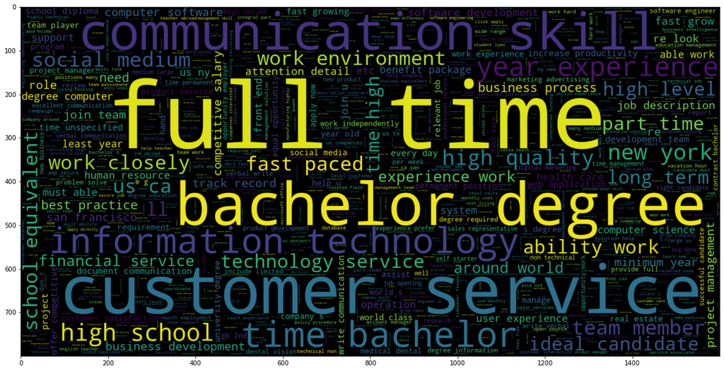

```python
import spacy
from spacy.lang.en.stop_words import STOP_WORDS
from spacy.lang.en import English
from wordcloud import WordCloud

plt.figure(figsize = (20,20)) # Text that is not fraudulent(0)
wc = WordCloud(width = 1600 , height = 800 , max_words = 3000).generate(" ".join(df[df.fraudulent == 0].text))
plt.imshow(wc , interpolation = 'bilinear')
```

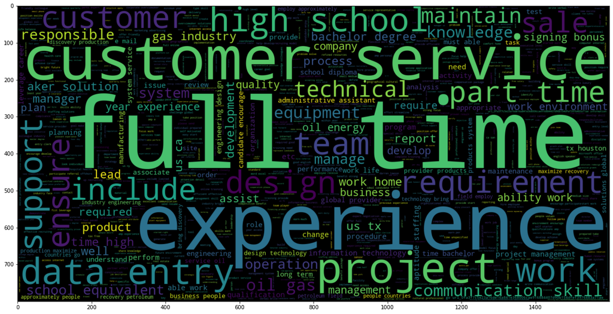

```python
plt.figure(figsize = (20,20)) # Text that is not fraudulent(0)
wc = WordCloud(width = 1600 , height = 800 , max_words = 3000).generate(" ".join(df[df.fraudulent == 1].text))
plt.imshow(wc , interpolation = 'bilinear')
```

## 6. Разбить данные на обучающую и тестовую выборки

```python
from sklearn.model_selection import train_test_split

train_data , test_data = train_test_split(df, test_size = 0.2 , random_state = 42)
train_data.reset_index(drop=True, inplace=True)
test_data.reset_index(drop=True, inplace=True)
```

```python
train_data.info()
```

```
<class 'pandas.core.frame.DataFrame'>
RangeIndex: 14304 entries, 0 to 14303
Data columns (total 5 columns):
 #   Column            Non-Null Count  Dtype
---  ------            --------------  -----
 0   telecommuting     14304 non-null  int64
 1   has_company_logo  14304 non-null  int64
 2   has_questions     14304 non-null  int64
 3   fraudulent        14304 non-null  int64
 4   text              14304 non-null  object
dtypes: int64(4), object(1)
memory usage: 558.9+ KB
```

```python
test_data.info()
```

```
<class 'pandas.core.frame.DataFrame'>
RangeIndex: 3576 entries, 0 to 3575
Data columns (total 5 columns):
 #   Column            Non-Null Count  Dtype
---  ------            --------------  -----
 0   telecommuting     3576 non-null   int64
 1   has_company_logo  3576 non-null   int64
 2   has_questions     3576 non-null   int64
 3   fraudulent        3576 non-null   int64
 4   text              3576 non-null   object
dtypes: int64(4), object(1)
memory usage: 139.8+ KB
```

Векторизуем текстовое описание вакансии

```python
from sklearn.feature_extraction.text import CountVectorizer

cv = CountVectorizer(max_features=1000, binary=False, ngram_range=(1, 3))
cv.fit(train_data.text)
```

```
CountVectorizer(max_features=1000, ngram_range=(1, 3))
```

```python
cv_train_data = train_data.join(pd.DataFrame(cv.transform(train_data.text).toarray()))
del cv_train_data['text']
```

```python
cv_test_data = test_data.join(pd.DataFrame(cv.transform(test_data.text).toarray()))
del cv_test_data['text']
```

```python
cv_train_data.head()
```

|  | telecommuting | has_company_logo | has_questions | fraudulent | 0 | 1 | 2 | 3 | 4 | 5 | ... | 990 | 991 | 992 | 993 | 994 | 995 | 996 | 997 | 998 | 999 |
| --- | --- | --- | --- | --- | --- | --- | --- | --- | --- | --- | --- | --- | --- | --- | --- | --- | --- | --- | --- | --- | --- |
| 0 | 0 | 1 | 1 | 0 | 0 | 0 | 2 | 0 | 0 | 0 | ... | 0 | 0 | 2 | 0 | 0 | 0 | 3 | 0 | 1 | 0 |
| 1 | 0 | 1 | 0 | 0 | 2 | 0 | 0 | 1 | 0 | 0 | ... | 0 | 0 | 2 | 0 | 0 | 0 | 0 | 0 | 0 | 0 |
| 2 | 0 | 1 | 1 | 0 | 0 | 0 | 0 | 0 | 0 | 0 | ... | 0 | 0 | 1 | 1 | 0 | 0 | 0 | 0 | 0 | 0 |
| 3 | 0 | 1 | 1 | 0 | 0 | 0 | 0 | 0 | 0 | 0 | ... | 0 | 0 | 0 | 0 | 0 | 0 | 0 | 0 | 0 | 0 |
| 4 | 0 | 0 | 0 | 0 | 0 | 0 | 0 | 0 | 0 | 0 | ... | 0 | 0 | 1 | 0 | 0 | 0 | 0 | 0 | 0 | 0 |

5 rows × 1004 columns

```python
cv_test_data.head()
```

|  | telecommuting | has_company_logo | has_questions | fraudulent | 0 | 1 | 2 | 3 | 4 | 5 | ... | 990 | 991 | 992 | 993 | 994 | 995 | 996 | 997 | 998 | 999 |
| --- | --- | --- | --- | --- | --- | --- | --- | --- | --- | --- | --- | --- | --- | --- | --- | --- | --- | --- | --- | --- | --- |
| 0 | 0 | 1 | 0 | 0 | 0 | 0 | 0 | 0 | 0 | 0 | ... | 0 | 0 | 0 | 0 | 0 | 0 | 0 | 0 | 0 | 0 |
| 1 | 1 | 0 | 0 | 0 | 0 | 0 | 0 | 0 | 0 | 0 | ... | 3 | 1 | 0 | 0 | 0 | 0 | 0 | 0 | 0 | 0 |
| 2 | 0 | 1 | 0 | 0 | 0 | 0 | 0 | 0 | 0 | 0 | ... | 1 | 0 | 1 | 0 | 0 | 1 | 0 | 0 | 0 | 0 |
| 3 | 0 | 1 | 0 | 0 | 0 | 0 | 0 | 0 | 0 | 1 | ... | 0 | 0 | 1 | 0 | 0 | 0 | 0 | 0 | 0 | 0 |
| 4 | 0 | 1 | 1 | 0 | 1 | 1 | 0 | 0 | 0 | 0 | ... | 0 | 0 | 1 | 0 | 0 | 0 | 0 | 0 | 0 | 0 |

5 rows × 1004 columns

```python
y_train = cv_train_data['fraudulent']
X_train = cv_train_data[cv_train_data.columns.drop('fraudulent')]
```

```python
y_test = cv_test_data['fraudulent']
X_test = cv_test_data[cv_test_data.columns.drop('fraudulent')]
```

## 7. Запустить классификатор ближайших соседей

```python
from sklearn.neighbors import KNeighborsClassifier
```

```python
model = KNeighborsClassifier()
model.fit(X_train, y_train)
```

```
KNeighborsClassifier()
```

```python
y_pred = model.predict(X_test)
```

```python
from sklearn.metrics import accuracy_score

accuracy_score(y_pred, y_test)
```

```
0.9608501118568232
```

```python
for k in range(1, 30):
    model = KNeighborsClassifier(n_neighbors=k)
    model.fit(X_train, y_train)
    y_pred = model.predict(X_test)
    print('k = {}, accuracy = {}'.format(k, accuracy_score(y_pred, y_test)))
```

```
k = 1, accuracy = 0.9619686800894854
k = 2, accuracy = 0.9711968680089486
k = 3, accuracy = 0.9614093959731543
k = 4, accuracy = 0.968400447427293
k = 5, accuracy = 0.9608501118568232
k = 6, accuracy = 0.9661633109619687
k = 7, accuracy = 0.9572147651006712
k = 8, accuracy = 0.9628076062639821
k = 9, accuracy = 0.9549776286353467
k = 10, accuracy = 0.959731543624161
k = 11, accuracy = 0.9530201342281879
k = 12, accuracy = 0.9644854586129754
k = 13, accuracy = 0.9608501118568232
k = 14, accuracy = 0.9672818791946308
k = 15, accuracy = 0.9644854586129754
k = 16, accuracy = 0.9661633109619687
k = 17, accuracy = 0.9650447427293065
k = 18, accuracy = 0.9661633109619687
k = 19, accuracy = 0.9650447427293065
k = 20, accuracy = 0.9664429530201343
k = 21, accuracy = 0.9650447427293065
k = 22, accuracy = 0.9650447427293065
k = 23, accuracy = 0.964765100671141
k = 24, accuracy = 0.9658836689038032
k = 25, accuracy = 0.9658836689038032
k = 26, accuracy = 0.9664429530201343
k = 27, accuracy = 0.9667225950782998
k = 28, accuracy = 0.9653243847874721
k = 29, accuracy = 0.9653243847874721
```

Лучшее качество

```python
model = KNeighborsClassifier(n_neighbors=2)
model.fit(X_train, y_train)
y_pred = model.predict(X_test)
print('k = {}, accuracy = {}'.format(2, accuracy_score(y_pred, y_test)))
```

```
k = 2, accuracy = 0.9711968680089486
```

```python
from sklearn.linear_model import LogisticRegression

model = LogisticRegression()
model.fit(X_train, y_train)
y_pred = model.predict(X_test)
accuracy_score(y_pred, y_test)
```

```
0.9773489932885906
```

```python
for c in [0.001, 0.01, 0.1, 1.0, 5.0, 10.0, 20.0, 50.0, 100.0]:
    model = LogisticRegression(C=c)
    model.fit(X_train, y_train)
    y_pred = model.predict(X_test)
    print('C = {}, accuracy = {}'.format(c, accuracy_score(y_pred, y_test)))
```

```
C = 0.001, accuracy = 0.9544183445190156
C = 0.01, accuracy = 0.9728747203579419
C = 0.1, accuracy = 0.9767897091722595
C = 1.0, accuracy = 0.9773489932885906
C = 5.0, accuracy = 0.9739932885906041
C = 10.0, accuracy = 0.9731543624161074
C = 20.0, accuracy = 0.9728747203579419
C = 50.0, accuracy = 0.9723154362416108
C = 100.0, accuracy = 0.9717561521252797
```

Лучшее качество

```python
model = LogisticRegression(C=1.)
model.fit(X_train, y_train)
y_pred = model.predict(X_test)
print('C = {}, accuracy = {}'.format(1., accuracy_score(y_pred, y_test)))
```

```
C = 1.0, accuracy = 0.9773489932885906
```

```python
from sklearn.tree import DecisionTreeClassifier

model = DecisionTreeClassifier()
model.fit(X_train, y_train)
y_pred = model.predict(X_test)
accuracy_score(y_pred, y_test)
```

```
0.9739932885906041
```

```python
for depth in [1, 2, 4, 8, 16, 32, 64]:
    model = DecisionTreeClassifier(max_depth=depth)
    model.fit(X_train, y_train)
    y_pred = model.predict(X_test)
    print('max_depth = {}, accuracy = {}'.format(depth, accuracy_score(y_pred, y_test)))
```

```
max_depth = 1, accuracy = 0.9493847874720358
max_depth = 2, accuracy = 0.9532997762863534
max_depth = 4, accuracy = 0.9608501118568232
max_depth = 8, accuracy = 0.968400447427293
max_depth = 16, accuracy = 0.9725950782997763
max_depth = 32, accuracy = 0.9745525727069351
max_depth = 64, accuracy = 0.9737136465324385
```

Лучшее качество

```python
model = DecisionTreeClassifier(max_depth=32)
model.fit(X_train, y_train)
y_pred = model.predict(X_test)
print('max_depth = {}, accuracy = {}'.format(32, accuracy_score(y_pred, y_test)))
```

```
max_depth = 32, accuracy = 0.9739932885906041
```

```python
from sklearn.ensemble import RandomForestClassifier

model = RandomForestClassifier()
model.fit(X_train, y_train)
y_pred = model.predict(X_test)
accuracy_score(y_pred, y_test)
```

```
0.9765100671140939
```

```python
for n in [1, 2, 4, 16, 32, 64, 128, 256, 512]:
    for depth in [1, 2, 4, 8, 16, 32, 64]:
        model = RandomForestClassifier(n_estimators = n, max_depth=depth, random_state=42)
        model.fit(X_train, y_train)
        y_pred = model.predict(X_test)
        print('max_depth = {}, n_estimators = {}, accuracy = {}'.format(depth, n, accuracy_score(y_pred, y_test)))
```

```
max_depth = 1, n_estimators = 1, accuracy = 0.9493847874720358
max_depth = 2, n_estimators = 1, accuracy = 0.9502237136465325
max_depth = 4, n_estimators = 1, accuracy = 0.9541387024608501
max_depth = 8, n_estimators = 1, accuracy = 0.9577740492170023
max_depth = 16, n_estimators = 1, accuracy = 0.9538590604026845
max_depth = 32, n_estimators = 1, accuracy = 0.959731543624161
max_depth = 64, n_estimators = 1, accuracy = 0.9569351230425056
max_depth = 1, n_estimators = 2, accuracy = 0.9493847874720358
max_depth = 2, n_estimators = 2, accuracy = 0.9513422818791947
max_depth = 4, n_estimators = 2, accuracy = 0.9530201342281879
max_depth = 8, n_estimators = 2, accuracy = 0.9563758389261745
max_depth = 16, n_estimators = 2, accuracy = 0.9628076062639821
max_depth = 32, n_estimators = 2, accuracy = 0.9697986577181208
max_depth = 64, n_estimators = 2, accuracy = 0.9723154362416108
max_depth = 1, n_estimators = 4, accuracy = 0.9493847874720358
max_depth = 2, n_estimators = 4, accuracy = 0.9493847874720358
max_depth = 4, n_estimators = 4, accuracy = 0.9516219239373602
max_depth = 8, n_estimators = 4, accuracy = 0.9611297539149888
max_depth = 16, n_estimators = 4, accuracy = 0.9703579418344519
max_depth = 32, n_estimators = 4, accuracy = 0.9742729306487695
max_depth = 64, n_estimators = 4, accuracy = 0.9748322147651006
max_depth = 1, n_estimators = 16, accuracy = 0.9493847874720358
max_depth = 2, n_estimators = 16, accuracy = 0.9493847874720358
max_depth = 4, n_estimators = 16, accuracy = 0.9516219239373602
max_depth = 8, n_estimators = 16, accuracy = 0.9614093959731543
max_depth = 16, n_estimators = 16, accuracy = 0.9703579418344519
max_depth = 32, n_estimators = 16, accuracy = 0.9773489932885906
max_depth = 64, n_estimators = 16, accuracy = 0.9762304250559284
max_depth = 1, n_estimators = 32, accuracy = 0.9493847874720358
max_depth = 2, n_estimators = 32, accuracy = 0.9493847874720358
max_depth = 4, n_estimators = 32, accuracy = 0.9496644295302014
max_depth = 8, n_estimators = 32, accuracy = 0.9608501118568232
max_depth = 16, n_estimators = 32, accuracy = 0.9695190156599552
max_depth = 32, n_estimators = 32, accuracy = 0.9765100671140939
max_depth = 64, n_estimators = 32, accuracy = 0.9767897091722595
max_depth = 1, n_estimators = 64, accuracy = 0.9493847874720358
max_depth = 2, n_estimators = 64, accuracy = 0.9493847874720358
max_depth = 4, n_estimators = 64, accuracy = 0.9493847874720358
max_depth = 8, n_estimators = 64, accuracy = 0.9608501118568232
max_depth = 16, n_estimators = 64, accuracy = 0.9706375838926175
```

[output cut: 8 more lines]

```
max_depth = 64, n_estimators = 128, accuracy = 0.9776286353467561
max_depth = 1, n_estimators = 256, accuracy = 0.9493847874720358
max_depth = 2, n_estimators = 256, accuracy = 0.9493847874720358
max_depth = 4, n_estimators = 256, accuracy = 0.9493847874720358
max_depth = 8, n_estimators = 256, accuracy = 0.9611297539149888
max_depth = 16, n_estimators = 256, accuracy = 0.9728747203579419
max_depth = 32, n_estimators = 256, accuracy = 0.9762304250559284
max_depth = 64, n_estimators = 256, accuracy = 0.9776286353467561
max_depth = 1, n_estimators = 512, accuracy = 0.9493847874720358
max_depth = 2, n_estimators = 512, accuracy = 0.9493847874720358
max_depth = 4, n_estimators = 512, accuracy = 0.9493847874720358
max_depth = 8, n_estimators = 512, accuracy = 0.9611297539149888
max_depth = 16, n_estimators = 512, accuracy = 0.9725950782997763
max_depth = 32, n_estimators = 512, accuracy = 0.9762304250559284
max_depth = 64, n_estimators = 512, accuracy = 0.9773489932885906
```

Лучшее качество

```python
model = RandomForestClassifier(n_estimators=128, max_depth=64, random_state=42)
model.fit(X_train, y_train)
y_pred = model.predict(X_test)
print('max_depth = {}, n_estimators = {}, accuracy = {}'.format(depth, n, accuracy_score(y_pred, y_test)))
```

```
max_depth = 64, n_estimators = 512, accuracy = 0.9776286353467561
```

### Выводы

```python
from sklearn.neural_network import MLPClassifier

model = MLPClassifier()
model.fit(X_train, y_train)
y_pred = model.predict(X_test)
accuracy_score(y_pred, y_test)
```

```
0.9835011185682326
```

```python
for layer_1 in [32, 64, 128, 256, 512, 1024, 2048]:
    model = MLPClassifier(hidden_layer_sizes=(layer_1,))
    model.fit(X_train, y_train)
    y_pred = model.predict(X_test)
    print('layer_1 = {}, accuracy = {}'.format(layer_1, accuracy_score(y_pred, y_test)))
```

```
layer_1 = 32, accuracy = 0.9840604026845637
layer_1 = 64, accuracy = 0.9835011185682326
layer_1 = 128, accuracy = 0.9843400447427293
layer_1 = 256, accuracy = 0.9848993288590604
layer_1 = 512, accuracy = 0.9848993288590604
layer_1 = 1024, accuracy = 0.9848993288590604
layer_1 = 2048, accuracy = 0.985738255033557
```

```python
for layer_1 in [32, 64, 128, 256, 512, 1024, 2048]:
    for layer_2 in [32, 64, 128, 256, 512, 1024, 2048]:
        model = MLPClassifier(hidden_layer_sizes=(layer_1, layer_2))
        model.fit(X_train, y_train)
        y_pred = model.predict(X_test)
        print('layer_1 = {}, layer_2 = {}, accuracy = {}'.format(layer_1, layer_2, accuracy_score(y_pred, y_test)))
```

```
layer_1 = 32, layer_2 = 32, accuracy = 0.982662192393736
layer_1 = 32, layer_2 = 64, accuracy = 0.9832214765100671
layer_1 = 32, layer_2 = 128, accuracy = 0.9837807606263982
layer_1 = 32, layer_2 = 256, accuracy = 0.985178970917226
layer_1 = 32, layer_2 = 512, accuracy = 0.9812639821029083
layer_1 = 32, layer_2 = 1024, accuracy = 0.982662192393736
layer_1 = 32, layer_2 = 2048, accuracy = 0.9823825503355704
layer_1 = 64, layer_2 = 32, accuracy = 0.9835011185682326
layer_1 = 64, layer_2 = 64, accuracy = 0.9835011185682326
layer_1 = 64, layer_2 = 128, accuracy = 0.9821029082774049
layer_1 = 64, layer_2 = 256, accuracy = 0.9848993288590604
layer_1 = 64, layer_2 = 512, accuracy = 0.9843400447427293
layer_1 = 64, layer_2 = 1024, accuracy = 0.9832214765100671
layer_1 = 64, layer_2 = 2048, accuracy = 0.9823825503355704
layer_1 = 128, layer_2 = 32, accuracy = 0.9835011185682326
layer_1 = 128, layer_2 = 64, accuracy = 0.9848993288590604
layer_1 = 128, layer_2 = 128, accuracy = 0.9829418344519015
layer_1 = 128, layer_2 = 256, accuracy = 0.9846196868008948
layer_1 = 128, layer_2 = 512, accuracy = 0.985178970917226
layer_1 = 128, layer_2 = 1024, accuracy = 0.9835011185682326
layer_1 = 128, layer_2 = 2048, accuracy = 0.9832214765100671
layer_1 = 256, layer_2 = 32, accuracy = 0.9843400447427293
layer_1 = 256, layer_2 = 64, accuracy = 0.9862975391498882
layer_1 = 256, layer_2 = 128, accuracy = 0.985178970917226
layer_1 = 256, layer_2 = 256, accuracy = 0.9846196868008948
layer_1 = 256, layer_2 = 512, accuracy = 0.9848993288590604
layer_1 = 256, layer_2 = 1024, accuracy = 0.9854586129753915
layer_1 = 256, layer_2 = 2048, accuracy = 0.9843400447427293
layer_1 = 512, layer_2 = 32, accuracy = 0.9860178970917226
layer_1 = 512, layer_2 = 64, accuracy = 0.9843400447427293
layer_1 = 512, layer_2 = 128, accuracy = 0.985738255033557
layer_1 = 512, layer_2 = 256, accuracy = 0.9843400447427293
layer_1 = 512, layer_2 = 512, accuracy = 0.985178970917226
layer_1 = 512, layer_2 = 1024, accuracy = 0.9840604026845637
layer_1 = 512, layer_2 = 2048, accuracy = 0.9874161073825504
layer_1 = 1024, layer_2 = 32, accuracy = 0.9865771812080537
layer_1 = 1024, layer_2 = 64, accuracy = 0.985178970917226
layer_1 = 1024, layer_2 = 128, accuracy = 0.985738255033557
layer_1 = 1024, layer_2 = 256, accuracy = 0.9862975391498882
layer_1 = 1024, layer_2 = 512, accuracy = 0.9860178970917226
layer_1 = 1024, layer_2 = 1024, accuracy = 0.9848993288590604
layer_1 = 1024, layer_2 = 2048, accuracy = 0.9860178970917226
layer_1 = 2048, layer_2 = 32, accuracy = 0.9837807606263982
layer_1 = 2048, layer_2 = 64, accuracy = 0.9846196868008948
layer_1 = 2048, layer_2 = 128, accuracy = 0.9860178970917226
layer_1 = 2048, layer_2 = 256, accuracy = 0.9860178970917226
layer_1 = 2048, layer_2 = 512, accuracy = 0.9865771812080537
layer_1 = 2048, layer_2 = 1024, accuracy = 0.985738255033557
layer_1 = 2048, layer_2 = 2048, accuracy = 0.985178970917226
```

```python
model = MLPClassifier(hidden_layer_sizes=(256, 32))
model.fit(X_train, y_train)
y_pred = model.predict(X_test)
print('layer_1 = {}, layer_2 = {}, accuracy = {}'.format(256, 32, accuracy_score(y_pred, y_test)))
```

```
layer_1 = 256, layer_2 = 32, accuracy = 0.9848993288590604
```

```python
for alpha in [0.0001, 0.001, 0.01, 0.1, 1.0]:
    model = MLPClassifier(hidden_layer_sizes=(256, 32), alpha=alpha)
    model.fit(X_train, y_train)
    y_pred = model.predict(X_test)
    print('alpha = {}, accuracy = {}'.format(alpha, accuracy_score(y_pred, y_test)))
```

```
alpha = 0.0001, accuracy = 0.9843400447427293
alpha = 0.001, accuracy = 0.9860178970917226
alpha = 0.01, accuracy = 0.9846196868008948
alpha = 0.1, accuracy = 0.9837807606263982
alpha = 1.0, accuracy = 0.9823825503355704
```

График зависимости качества от параметра alpha

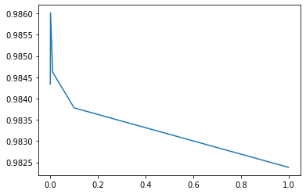

```python
fig, ax = plt.subplots()
ax.plot(
    [0.0001, 0.001, 0.01, 0.1, 1.0],
    [0.9843400447427293, 0.9860178970917226, 0.9846196868008948, 0.9837807606263982, 0.9823825503355704]
)
```

График зависимости качества от количества нейронов

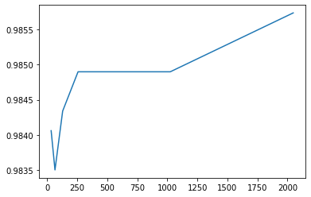

```python
fig, ax = plt.subplots()
ax.plot(
    [32, 64, 128, 256, 512, 1024, 2048],
    [
        0.9840604026845637,
        0.9835011185682326,
        0.9843400447427293,
        0.9848993288590604,
        0.9848993288590604,
        0.9848993288590604,
        0.985738255033557
    ]
)
```

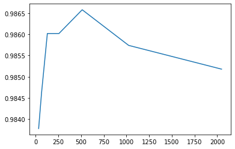

```python
fig, ax = plt.subplots()
ax.plot(
    [32, 64, 128, 256, 512, 1024, 2048],
    [
        0.9837807606263982,
        0.9846196868008948,
        0.9860178970917226,
        0.9860178970917226,
        0.9865771812080537,
        0.985738255033557,
        0.985178970917226
    ]
)
```

При использовании в первом слое 2048 нейронов, наблюдается несколько другая картина. Сначала при увеличении количества нейронов качество возрастает, затем начинает падать, что говорит о том, что при слишком большом количестве параметров сеть начинает переобучаться на обучающих данных, что негативно сказывается на результатах тестового датасета.

Лучшее качество

```python
model = MLPClassifier(hidden_layer_sizes=(256, 32), alpha=0.001)
model.fit(X_train, y_train)
y_pred = model.predict(X_test)
print('alpha = {}, accuracy = {}'.format(0.001, accuracy_score(y_pred, y_test)))
```

```
alpha = 0.001, accuracy = 0.9848993288590604
```

Полностьюсвязная нейронная сеть с двумя скрытыми слоями достигает наилучшее качество. При этом в ходе экспериментов стало понятно, что не всегда имеет смысл увеличивать каличетсво нейронов в разных слоях сети, так как это может привести к переобучению, а так же слишком негативно сказаться на времени работы классификатора.